# Cox Proportional Hazards Model

Halley Deleeuw and Jasmine Sawh

2023-11-20

## Literature Review

#### Introduction to Cox Proportional Hazards Model

The Cox Proportional Hazard model is a powerful took for survival analysis. In this section, I will review several key articles that shed light on its applications and implications. Two insightful articles provide a foundation understanding of the Cox Proportional Hazard model.The first paper by Abeysekera (W. W. M. Abeysekera 2009) was helpful when understanding the baseline of Cox Proportional Hazard model. It uses the model to check if the Proportional Hazards Assumptions are true. In order to test this they used the the global goodness-of-fit test proposed by Schoenfeld. The authors used an example from a clinical study involving heroin addicts who were getting methadone treatments. There were three components that were looked at which were the highest meth dose, addicts with a criminal record vs not, and how long they were treated at a clinic. What I really enjoyed about this paper and what I want to make note of is the math and coding behind the method. It explained it really well and included the code on the bottom of the paper. The second link was different but also helpful as well (Jianqing Fan 2002). The purpose of this one is to discuss variable selection techniques to the Cox Proportional Hazard model. I wanted to note this one since this can help my partner and I when it comes to approaching a data set and identifying the most important predictors. This paper doesn’t go into particular depth of a hazard model like the first one. However, it shows the mathematical reasoning to choose a predictor and the outcome of the model when using their approach.

#### Application of Cox Proportional Hazards Model

Equeter takes a unique angle by predicting tool lifespan in machining (Lucas Equeter 2020). It focuses on predicting the Mean Up Time of cutting tool insets based on a single cutting parameter: cutting speed. They employed the model for the predication and did so by transforming the data. Although I was confused at the use of the Cox Proportional Hazard model, the authors thought it was a good fit for assessing tool lifespan and has been used in previous machining studies. The first step the author does is generate degradation paths using a gamma process. The gamma process is employed to generate a set of tool lifetimes. Another part that I was surprised in was the author used a logarithmic transformation of cutting speed in order to improve in prediction performance. In addition, the author uses a piece wise stochastic model for flank wear in order to see the effects at the beginning to the end of the tool life. This paper is helpful when looking at appropriate data for using the Cox Proportional Hazard model. I would like to revisit it when my partner and I want to pick a data set as it sets out important notes to consider such as data transformation, logarithmic transformation and size of the data.

#### Approaches and Presuppositions

Understanding the methods and assumptions behind the Cox Proportional Hazard model is essential for its effective application. Faruk delves into the model’s methodology (Faruk 2018). The researchers used data from the 2012 Indonesian Demographic and Health Survey for the first birth interval. They compared the performance of the model to the three accelerated failure time models by Weibull, exponential and log-normal distributions. The data was assessed for violations of the assumption through log cumulative hazard plots and statistical tests. In the paper, one shortfall that I feel wasn’t addressed was the results of the analysis of the data. It was discussed how they employed the log cumulative hazard plots and Goodness-Of-Fit test. The analysis identified significant covariates, including women’s education level, husband’s education level, contraceptive knowledge, access to mass media, wealth index, and employment status.

Deo applies the Cox Proportional Hazard model to study post-surgical patients with stage 3 lung cancer (Salil Vasudeo Deo 2021). The authors calculated the survival estimates using the Kaplan-Meier estimates, which I discuss and reference in a different article. They used log-rank test to compare the survival rates between the two groups (males and females). They discuss the advantages and disadvantages of using log-rank test. Then they discuss the assumptions of the CPH test and how it is advantageous for clinical research. They observed that patients that are the same age, females have a 41% reduced risk of mortality and a 1 unit increase in age increases the risk of mortality by 1%.

Fox uses Cox Proportional Hazard in a different light. The researchers used the Rossi data set in the carData package in R(John Fox 2023). The data explores recidivism rates among males in a prison. They created a Cox regression time of re-arrest. They went into detail about how to read the output of the different coefficients. Then, they showed a graph of the estimated survival prediction. There is a specific package in r called Survival, which is useful for this type of analysis.

Similarly, Bland goes into depth on what the log-rank test is (J Martin Bland 2004). It is used to compare the survival rates between two groups. The log-rank test gives a comparison at some arbitrary point in the point, instead of comparing the whole survival time to one another. The log-rank test is also based on the same assumptions as the Kaplan test. The log-rank test is also more likely to detect a different in the groups when the risk for the outcome of interest is higher in one of the groups.

The goal of this study is to see whether hazard ration, relative risk, and other estimates made by the Cox Proportional Hazards model are biased when the basic assumptions of the model are violated(W. W. M. Abeysekera 2009). This is very important because whenever regression models are run, not just Cox Proportional Hazards models, many times we take for granted that the assumptions of the model are met. This can lead to incorrect conclusions and predictions. The Cox model assumes that the hazard ratios remain constant over time. If this is violated, then the model may falsely suggest that a variable is significant or vice versa. This study showed an example where the hazards ratio is not constant over time. An example was with the age of smokers and the RR as age increased. As there was an increase in cumulative smoking exposure, the RR decrease after 50. It was also addressed how in the Cox PH model, there is increased emphasis on the Relative Risk. This is convenient because it doesn’t require estimating background information. They first examined survival curves by smoking status and then compared a simulated data set could define mortality to a real data set. They found that single minded focus on PH models have hindered the development of other models in epidemiological data. Sometimes hazard functions, rather than the rate of hazard functions may be a better alternative.

Lastly, Kuitunen and his team highlighted the reporting and adequacy of model details in total join arthroplasty studies(Ilari Kuitunen 2021). It investigates, in detail, the reporting of the model details as well as the model assumptions with total joint arthroplasty studies. Nearly 80% of the Cox proportional hazards were reported inadequately. However, it is still among the most used models. One of the solutions was to hire statisticians to review the process and make sure reproducible results are created.

Another application of the model was when it was testing the strength of proportional hazards in total joint arthroplasty studies(Ville T. Ponkilainene 2021). They found a total of 1154 studies by searching for “cox” AND “hazard” in the abstract. The abstract also had to meet the following criteria: the topic must be on knee or hip joint arthroplasty, survival analysis was used, and a hazard ratio was reported. If those criteria were met, the entire article was read. Nearly 80% of the published TJA survival studies reported proportional hazard assumptions of the Cox regression model inadequately. Also, more than one-fifth of the studies were found to include a probable non-proportional Cox model.

The model can also be used to study the relationship between sleepiness and prediction of a driver’s impairment(Anna Vadeby 2010). The approach was to only use the parametric part of the hazard function to study changes in risk of a critical event (lane change) due to changes in the explanatory variables (indicators). The probability of a critical event is proportional to the hazard function and therefore the changes in risk can be estimated by changes in the hazard function. All co-variates were statistically significant.

In this literature review, we have explored the foundational concepts of the Cox Proportional Hazard model, its diverse applications, and the methods and assumptions underlying its use. These studies collectively showcase the model’s significance in diverse fields and the need to critically assess its assumptions and reporting for reliable results.

## Introduction

Cox Proportional Hazard model is a statistical method that has been used for survival analysis and epidemiological research. The model emerged in 1972 by Sir David R. Cox. The model provides researchers with a robust framework for understanding time-to-event data. It uses a semi-parametric estimator that focuses on estimating the hazard function which represents the instantaneous risk of an event occurring at a given time. The purpose of Cox Proportional Hazards regression is to find the relationship between one or more independent variables and the hazard function while allowing for the exploration in non-linearity and time-varying effects(W. W. M. Abeysekera 2009).

The fundamental principles of the Cox Proportional Hazard model and its applications range across various research domains. The model primarily focuses on estimating the hazard function, which represents the instantaneous risk of an event occurring at any given time. The dependent variable in a hazard model consist of two parts, the first part is the event indicator and the second part is a measure of time (Ville T. Ponkilainene 2021). The model provides invaluable insights across diverse fields such as healthcare, engineering, social sciences, and beyond. It unravels the relationship between covariates and the hazard rate which represents the instantaneous risk of an event occurring at a given time.

Although the diversity with the Cox Proportional Hazard model is myriad, it still has its limitations. Not every data set is fit for the model and can present more issues when using the model to conduct research. In the context of this paper, we delve into a cancer data set sourced from the National Cancer Institute’s Surveillance, Epidemiology, and End Results (SEER) Program. Our objective is to scrutinize variables such as site record, sex, age record, cause of death to site record, death classification, and ethnicity, seeking to unveil the factors that influence the time until death. As our analysis unfolds, we aim to shed light on the intricate relationships within the data set and explore the broader implications of our findings.

In the subsequent sections, we will delve deeper into the intricacies of the data set and the methodology employed in our analysis, further illuminating the applications and implications of the Cox Proportional Hazard model in the context of our research.

## Methods

The Cox Proportional Hazard Model is a widely used semiparametric survival analysis method that provides a flexible framework for modeling the hazard rate in the presence of right-censored data. Right-censored data is a type of data where the event of interest like death or failure has not occurred for some of the subjects int he study by the end of observation period. Thus, the exact event time is unknown or not observed for these subjects. In this model, the hazard rate at any time point is expressed as the product of a baseline hazard function, denoted as λ0(t) and an exponential function of a linear combination of covariates.

Mathematically, the Cox model can be defined as:

$$λ(t) = λ0(t) * exp(β₁X₁ + β₂X₂ + ... + βₖXₖ)$$
This is where: $λ(t)$ represents the hazard rate at time t. $λ0(t)$ is the baseline hazard function, representing the hazard in the absence of covariates. $β₁, β₂, ..., βₖ$ are coefficients associated with covariates$X₁, X₂, ..., Xₖ,$ respectively.

#### Assumptions

Proportional Hazards Assumption - This assumption of the Cox model states that the effect of covariates on the hazard rate remains constant and is not time-dependent. The hazard ratio between two individuals should stay consistent over time if one individual’s covariate values are a constant factor of the other’s.

Independence of Censoring - The model assumes that the censoring process (the event of not observing the outcome) is independent of the event of interest. Hence, censoring process is not related to the underlying risk of the event.

Linearity of Continuous Variables - The model assumes that the log-hazard is a linear function of the covariates for continuous variables. A unit change in the covariate leads to a constant multiplicative change in the hazard rate.

## Analysis and Results

### Data Description

The data we are using in this study is provided by the National Cancer Institute Surveillance, Epidemiology, and End Results Program also known as SEER. It is a comprehensive cancer surveillance system in the United States. SEER collects and reports data related to cancer incidence, prevalence, survival and mortality. It covers a wide range of demographic, clinical, and tumor-related information for cancer research, prevention, and patience care, making it a valuable resource for understanding cancer trends, outcomes, and risk factors at a national level. This data set will be used as the foundation data set for my Cox Proportional Hazard models.

```r
# loading packages
library(tidyverse)
library(knitr)
library(kableExtra)
library(ggthemes)
library(ggrepel)
library(dslabs)
library(survival)
library(dplyr)
library(survival)
library(gtsummary)
library(gt)
library(htmlTable)
library(IRdisplay)
library(kableExtra)
library(ggplot2)
library(gridExtra)
library(scales)
library(ggplot2)
```

```r
Seer_updated<- read.csv("Seer_updated.csv")

df <- Seer_updated %>%
  rename(
    Age = Age.recode.with.single.ages.and.85.,
    Race = Race.ethnicity,
    Sex = Sex,
    Origin = Origin.recode.NHIA..Hispanic..Non.Hisp.,
    Year.of.diagnosis = Year.of.diagnosis,
    Survival.months = Survival.months,
    COD_Site =COD.to.site.recode,
    Primary.Site = Primary.Site,
    Median_Household_Income = Median.household.income.inflation.adj.to.2019
  ) %>%
  mutate(survived = ifelse(COD_Site == "Alive", 0, 1))

  df$Age <- sub(" years", "", df$Age)
  df$Age <- as.numeric(df$Age)
  df$Survival.months <- as.numeric(df$Survival.months)
  df$Race_Category <- case_when(
  df$Race %in% c("White") ~ "White",
  df$Race %in% c("Black") ~ "Black",
  df$Race %in% c("Asian Indian", "Asian Indian or Pakistani", "Chinese", "Japanese", "Korean", "Thai", "Vietnamese", "Other Asian") ~ "Asian",
  df$Race %in% c("Chamorran", "Fiji Islander", "Guamanian", "Hawaiian", "Micronesian", "Samoan", "Tahitian", "Tongan", "Pacific Islander") ~ "Pacific      Islander",
  TRUE ~ "Other/Miscellaneous"
)
df <- df %>%
  mutate(
    Cancer_Group = case_when(
      df$COD_Site %in% c("Colon excluding Rectum", "Rectum and Rectosigmoid Junction") ~ "Colorectal",
      df$COD_Site %in% c("Lung and Bronchus") ~ "Lung Cancer",
      df$COD_Site %in% c("Pancreas") ~ "Pancreatic Cancer",
      df$COD_Site %in% c("Breast") ~ "Breast Cancer",
      df$COD_Site %in% c("Prostate") ~ "Prostate Cancer",
      TRUE ~ "Other"
    )
  )
styled_table <- df %>%
  select(
    Age,
    Race_Category,
    Sex,
    survived,
    Origin,
    Year.of.diagnosis,
    Survival.months,  # Modified to use the numeric "Survival.months"
    Cancer_Group,
    Median_Household_Income
  ) %>%
  tbl_summary(
    type = list(
      Age ~ 'continuous2',
      Race_Category ~ 'categorical',
      Sex ~ 'categorical',
      Origin ~ 'categorical',
      Year.of.diagnosis ~ 'continuous2',
      Survival.months ~ 'continuous2',  # Using "Survival.months" as a continuous variable
      Cancer_Group ~ 'categorical',
      Median_Household_Income ~ 'categorical'
    ),
    label = list(
      Age ~ "Patient Age",
      Race_Category ~ "Patient Race",
      Sex ~ "Patient Gender",
      Origin ~ "Patient's Origin",
      Year.of.diagnosis ~ "Year of Diagnosis",
      Survival.months ~ "# of months after diagnosis",
      Cancer_Group ~ "Cause of Death Type",
      Median_Household_Income ~ "Median Household Income"
    ),
    statistic = all_continuous() ~ c("{median} ({p25}, {p75})", "{min}, {max}"),
    by = survived
  ) %>%
 add_overall(last = TRUE) %>%
  bold_labels() %>%
  italicize_levels()
# Export the styled table to an HTML file
html_table <- styled_table %>%
  as_gt() %>%
  gt::as_raw_html()
# Save the HTML table to a file
writeLines(html_table, "styled_table.html")

styled_table %>%
  as_gt() %>%
  gt::as_raw_html()
```

| **Characteristic** | **0**, N = 454,973<sup>1</sup> | **1**, N = 113,068<sup>1</sup> | **Overall**, N = 568,041<sup>1</sup> |
| --- | --- | --- | --- |
| Patient Age |  |  |  |
| Median (IQR) | 61 (51, 69) | 66 (58, 72) | 62 (53, 70) |
| Range | 25, 79 | 25, 79 | 25, 79 |
| Patient Race |  |  |  |
| Asian | 11,834 (2.6%) | 2,363 (2.1%) | 14,197 (2.5%) |
| Black | 48,438 (11%) | 15,843 (14%) | 64,281 (11%) |
| Other/Miscellaneous | 44,118 (9.7%) | 8,058 (7.1%) | 52,176 (9.2%) |
| Pacific Islander | 2,353 (0.5%) | 570 (0.5%) | 2,923 (0.5%) |
| White | 348,230 (77%) | 86,234 (76%) | 434,464 (76%) |
| Patient Gender |  |  |  |
| Female | 333,658 (73%) | 51,662 (46%) | 385,320 (68%) |
| Male | 121,315 (27%) | 61,406 (54%) | 182,721 (32%) |
| Patient's Origin |  |  |  |
| Non-Spanish-Hispanic-Latino | 383,708 (84%) | 95,386 (84%) | 479,094 (84%) |
| Spanish-Hispanic-Latino | 71,265 (16%) | 17,682 (16%) | 88,947 (16%) |
| Year of Diagnosis |  |  |  |
| Median (IQR) | 2,018 (2,017, 2,019) | 2,017 (2,016, 2,018) | 2,018 (2,017, 2,019) |
| Range | 2,016, 2,019 | 2,016, 2,019 | 2,016, 2,019 |
| # of months after diagnosis |  |  |  |
| Median (IQR) | 20 (9, 33) | 6 (2, 14) | 16 (6, 30) |
| Range | 0, 47 | 0, 47 | 0, 47 |
| Unknown | 1 | 3,707 | 3,708 |
| Cause of Death Type |  |  |  |
| Breast Cancer | 0 (0%) | 9,246 (8.2%) | 9,246 (1.6%) |
| Colorectal | 0 (0%) | 18,471 (16%) | 18,471 (3.3%) |
| Lung Cancer | 0 (0%) | 1,605 (1.4%) | 1,605 (0.3%) |
| Other | 454,973 (100%) | 60,005 (53%) | 514,978 (91%) |
| Pancreatic Cancer | 0 (0%) | 23,449 (21%) | 23,449 (4.1%) |
| Prostate Cancer | 0 (0%) | 292 (0.3%) | 292 (<0.1%) |
| Median Household Income |  |  |  |
| $35,000 - $39,999 | 8,580 (1.9%) | 2,891 (2.6%) | 11,471 (2.0%) |
| $40,000 - $44,999 | 17,476 (3.8%) | 5,765 (5.1%) | 23,241 (4.1%) |
| $45,000 - $49,999 | 19,887 (4.4%) | 6,261 (5.5%) | 26,148 (4.6%) |
| $50,000 - $54,999 | 36,463 (8.0%) | 10,655 (9.4%) | 47,118 (8.3%) |
| $55,000 - $59,999 | 22,093 (4.9%) | 6,077 (5.4%) | 28,170 (5.0%) |
| $60,000 - $64,999 | 42,625 (9.4%) | 11,067 (9.8%) | 53,692 (9.5%) |
| $65,000 - $69,999 | 97,860 (22%) | 24,908 (22%) | 122,768 (22%) |
| $70,000 - $74,999 | 34,660 (7.6%) | 7,641 (6.8%) | 42,301 (7.4%) |
| $75,000+ | 168,833 (37%) | 35,392 (31%) | 204,225 (36%) |
| < $35,000 | 6,471 (1.4%) | 2,406 (2.1%) | 8,877 (1.6%) |
| Unknown/missing/no match/Not 1990-2018 | 25 (<0.1%) | 5 (<0.1%) | 30 (<0.1%) |

<sup>1</sup> n (%)

```r
styled_table %>%
  kable() %>%
  kable_styling(full_width = FALSE)
```

| **Characteristic** | **0**, N = 454,973 | **1**, N = 113,068 | **Overall**, N = 568,041 |
| --- | --- | --- | --- |
| __Patient Age__ | NA | NA | NA |
| _Median (IQR)_ | 61 (51, 69) | 66 (58, 72) | 62 (53, 70) |
| _Range_ | 25, 79 | 25, 79 | 25, 79 |
| __Patient Race__ | NA | NA | NA |
| _Asian_ | 11,834 (2.6%) | 2,363 (2.1%) | 14,197 (2.5%) |
| _Black_ | 48,438 (11%) | 15,843 (14%) | 64,281 (11%) |
| _Other/Miscellaneous_ | 44,118 (9.7%) | 8,058 (7.1%) | 52,176 (9.2%) |
| _Pacific Islander_ | 2,353 (0.5%) | 570 (0.5%) | 2,923 (0.5%) |
| _White_ | 348,230 (77%) | 86,234 (76%) | 434,464 (76%) |
| __Patient Gender__ | NA | NA | NA |
| _Female_ | 333,658 (73%) | 51,662 (46%) | 385,320 (68%) |
| _Male_ | 121,315 (27%) | 61,406 (54%) | 182,721 (32%) |
| __Patient's Origin__ | NA | NA | NA |
| _Non-Spanish-Hispanic-Latino_ | 383,708 (84%) | 95,386 (84%) | 479,094 (84%) |
| _Spanish-Hispanic-Latino_ | 71,265 (16%) | 17,682 (16%) | 88,947 (16%) |
| __Year of Diagnosis__ | NA | NA | NA |
| _Median (IQR)_ | 2,018 (2,017, 2,019) | 2,017 (2,016, 2,018) | 2,018 (2,017, 2,019) |
| _Range_ | 2,016, 2,019 | 2,016, 2,019 | 2,016, 2,019 |
| __# of months after diagnosis__ | NA | NA | NA |
| _Median (IQR)_ | 20 (9, 33) | 6 (2, 14) | 16 (6, 30) |
| _Range_ | 0, 47 | 0, 47 | 0, 47 |
| _Unknown_ | 1 | 3,707 | 3,708 |
| __Cause of Death Type__ | NA | NA | NA |
| _Breast Cancer_ | 0 (0%) | 9,246 (8.2%) | 9,246 (1.6%) |
| _Colorectal_ | 0 (0%) | 18,471 (16%) | 18,471 (3.3%) |
| _Lung Cancer_ | 0 (0%) | 1,605 (1.4%) | 1,605 (0.3%) |
| _Other_ | 454,973 (100%) | 60,005 (53%) | 514,978 (91%) |
| _Pancreatic Cancer_ | 0 (0%) | 23,449 (21%) | 23,449 (4.1%) |
| _Prostate Cancer_ | 0 (0%) | 292 (0.3%) | 292 (<0.1%) |
| __Median Household Income__ | NA | NA | NA |
| _$35,000 - $39,999_ | 8,580 (1.9%) | 2,891 (2.6%) | 11,471 (2.0%) |
| _$40,000 - $44,999_ | 17,476 (3.8%) | 5,765 (5.1%) | 23,241 (4.1%) |
| _$45,000 - $49,999_ | 19,887 (4.4%) | 6,261 (5.5%) | 26,148 (4.6%) |
| _$50,000 - $54,999_ | 36,463 (8.0%) | 10,655 (9.4%) | 47,118 (8.3%) |
| _$55,000 - $59,999_ | 22,093 (4.9%) | 6,077 (5.4%) | 28,170 (5.0%) |
| _$60,000 - $64,999_ | 42,625 (9.4%) | 11,067 (9.8%) | 53,692 (9.5%) |
| _$65,000 - $69,999_ | 97,860 (22%) | 24,908 (22%) | 122,768 (22%) |
| _$70,000 - $74,999_ | 34,660 (7.6%) | 7,641 (6.8%) | 42,301 (7.4%) |
| _$75,000+_ | 168,833 (37%) | 35,392 (31%) | 204,225 (36%) |
| _< $35,000_ | 6,471 (1.4%) | 2,406 (2.1%) | 8,877 (1.6%) |
| _Unknown/missing/no match/Not 1990-2018_ | 25 (<0.1%) | 5 (<0.1%) | 30 (<0.1%) |

### Data Visualization

This portion of the paper will provide an understanding of the variables that contribute to survival. The graphs below serve as a preliminary exploration of key demographic elements within our study cohort, encompassing variables such as gender, race, geographic origin, and temporal dynamics indicated by the year of diagnosis.In addition to demographic profiling, we include visual observation of the diversity of cancer types prevalent in the data set.

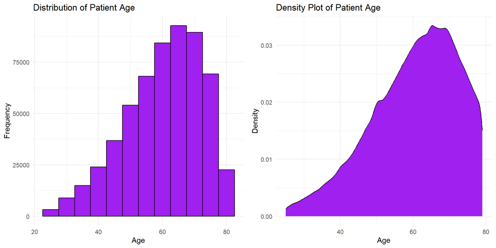

```r
histogram_plot <- ggplot(df, aes(x = Age)) +
  geom_histogram(binwidth = 5, fill = "purple", color = "black") +
  labs(title = "Distribution of Patient Age",
       x = "Age",
       y = "Frequency") +
  theme_minimal()


density_plot <- ggplot(df, aes(x = Age)) +
  geom_density(fill = "purple", color = "black") +
  labs(title = "Density Plot of Patient Age",
       x = "Age",
       y = "Density") +
  theme_minimal()

grid.arrange(histogram_plot, density_plot, ncol = 2)
```

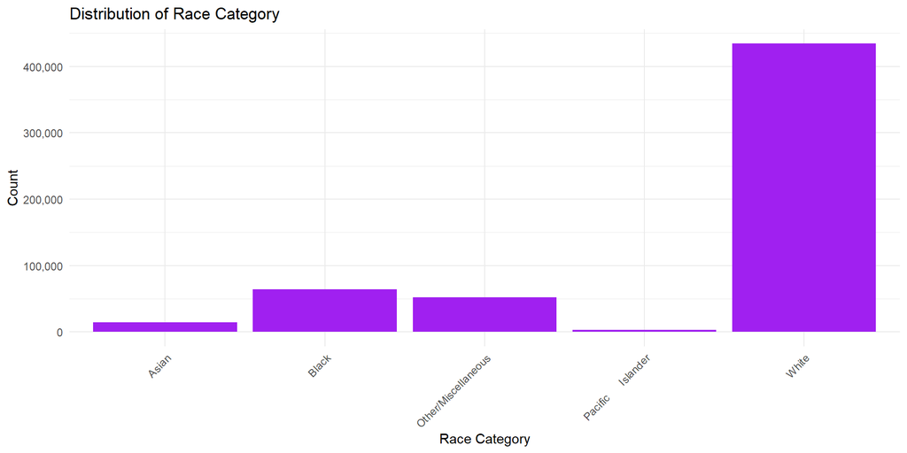

```r
bar_plot <- ggplot(df, aes(x = Race_Category)) +
  geom_bar(fill = "purple") +
  labs(title = "Distribution of Race Category",
       x = "Race Category",
       y = "Count") +
  theme_minimal() +
  theme(axis.text.x = element_text(angle = 45, hjust = 1)) +
  scale_y_continuous(labels = comma)

bar_plot
```

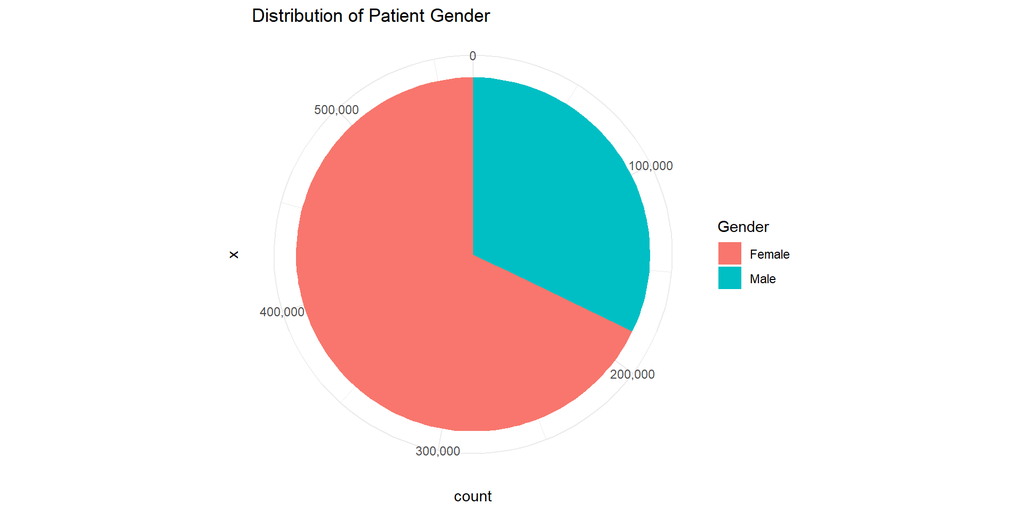

```r
pie_chart <- ggplot(df, aes(x = "", fill = Sex)) +
  geom_bar(width = 1) +
  coord_polar(theta = "y") +
  labs(title = "Distribution of Patient Gender",
       fill = "Gender") +
  theme_minimal() +
  scale_y_continuous(labels = comma)

pie_chart
```

Below is the distribution of the patient origin. It is split into two categories. Non-Spanish-Hispanic-Latino and Spanish-Hispanic-Latino.

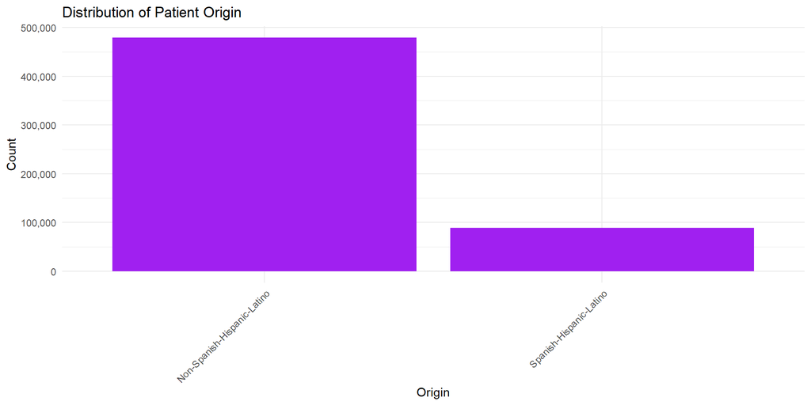

```r
bar_plot <- ggplot(df, aes(x = Origin)) +
  geom_bar(fill = "purple") +
  labs(title = "Distribution of Patient Origin",
       x = "Origin",
       y = "Count") +
  scale_y_continuous(labels = comma) +
  theme_minimal() +
  theme(axis.text.x = element_text(angle = 45, hjust = 1))

bar_plot
```

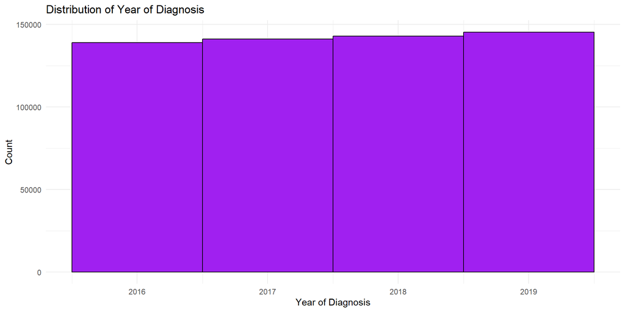

```r
histogram_plot <- ggplot(df, aes(x = Year.of.diagnosis)) +
  geom_histogram(binwidth = 1, fill = "purple", color = "black") +
  labs(title = "Distribution of Year of Diagnosis",
       x = "Year of Diagnosis",
       y = "Count") +
  theme_minimal()

histogram_plot
```

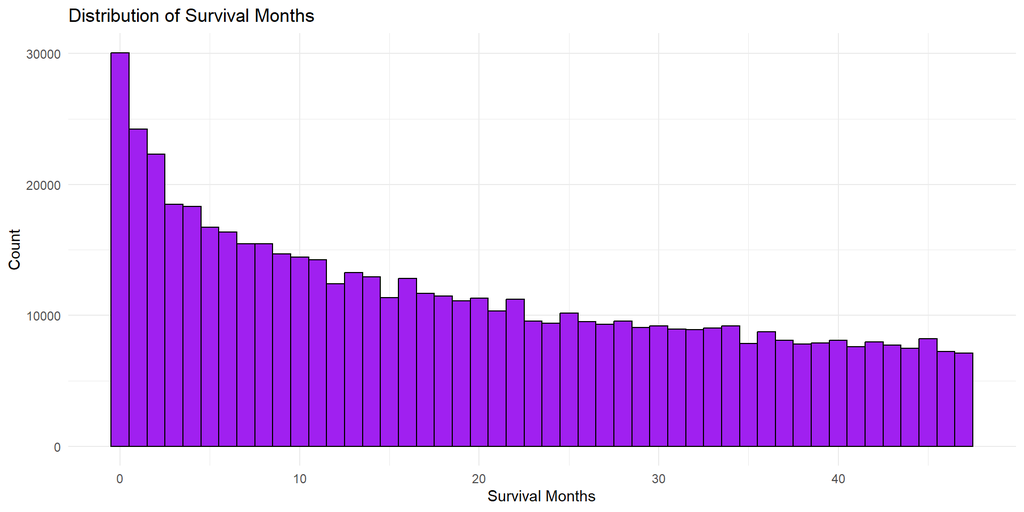

```r
histogram_plot <- ggplot(df, aes(x = Survival.months)) +
  geom_histogram(binwidth = 1, fill = "purple", color = "black") +
  labs(title = "Distribution of Survival Months",
       x = "Survival Months",
       y = "Count") +
  theme_minimal()

histogram_plot
```

Below is the distribution of the type of cancers in the data set. When analyzing the data, we notice that there is a m=higher count of others compared to breast cancer, colorectal, lung cancer, pancreatic cancer and prostate cancer.

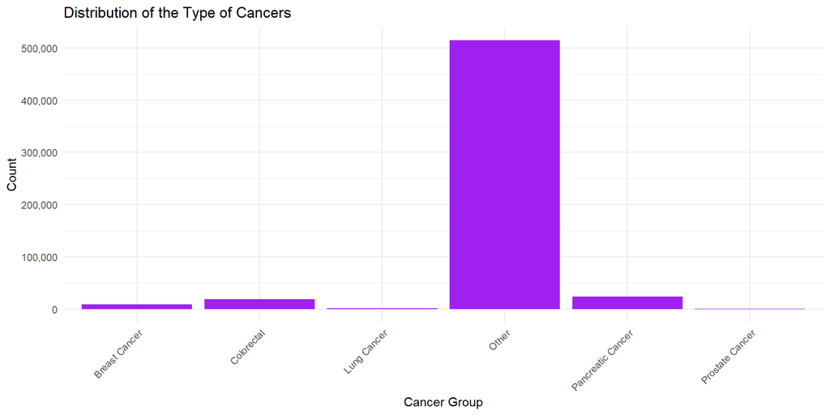

```r
bar_plot <- ggplot(df, aes(x = Cancer_Group)) +
  geom_bar(fill = "purple") +
  labs(title = "Distribution of the Type of Cancers",
       x = "Cancer Group",
       y = "Count") +
  scale_y_continuous(labels = comma) +
  theme_minimal() +
  theme(axis.text.x = element_text(angle = 45, hjust = 1))

bar_plot
```

Below is a distribution of those who were diagnosed and are still alive. We can see that many with breast cancer are still alive, as well as kidney and thyroid cancer.

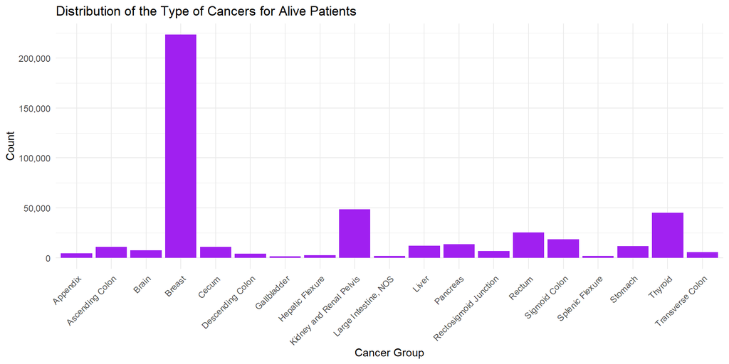

```r
alive_data <- df[df$survived == 0, ]
alive_data2 <- alive_data %>%
  rename(Cancer_type = Site.recode.ICD.O.3.WHO.2008)
bar_plot2 <- ggplot(alive_data2, aes(x = Cancer_type)) +
  geom_bar(fill = "purple") +
  labs(title = "Distribution of the Type of Cancers for Alive Patients",
       x = "Cancer Group",
       y = "Count") +
  scale_y_continuous(labels = comma) +
  theme_minimal() +
  theme(axis.text.x = element_text(angle = 45, hjust = 1))

bar_plot2
```

Below is a distribution of those who were diagnosed and are now deceased. Based on the bar graph, pancreatic cancer is the most susceptible to mortality, followed by liver cancer and breast cancer.

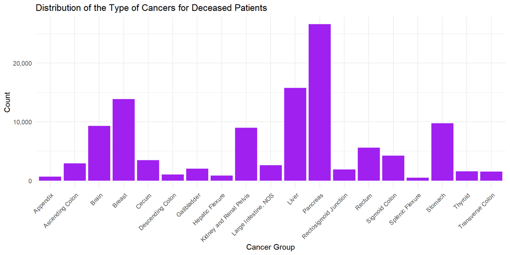

```r
dead_data <- df[df$survived == 1, ]
dead_data2 <- dead_data %>%
  rename(Cancer_type = Site.recode.ICD.O.3.WHO.2008)
bar_plot3 <- ggplot(dead_data2, aes(x = Cancer_type)) +
  geom_bar(fill = "purple") +
  labs(title = "Distribution of the Type of Cancers for Deceased Patients",
       x = "Cancer Group",
       y = "Count") +
  scale_y_continuous(labels = comma) +
  theme_minimal() +
  theme(axis.text.x = element_text(angle = 45, hjust = 1))

bar_plot3
```

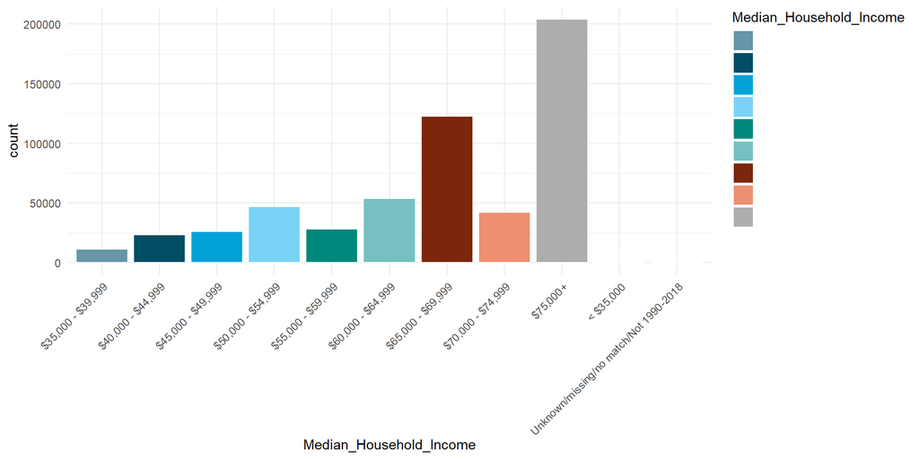

```r
ggplot(df, aes(x = Median_Household_Income, fill=Median_Household_Income)) +
  geom_bar(color="white") +
  theme_minimal(base_family="ITC Officina Sans") +
  scale_fill_economist(labels=NULL) +
  theme(axis.text.x = element_text(angle = 45, hjust = 1, vjust=1))
```

## Statistical Modeling

In the below, we will use Cox Proportional Model to perform survival analysis. Coxph is a function from the survival package in R. Our primary objective is to examine the determinants influencing survival outcomes within a diverse data set of patients. Utilizing the Cox Proportional Hazard model, we explore the impact of key variables such as cancer type, race, gender, age, etc on the likelihood of survival. Our analysis centered on exploring these variables and their associated hazard ratios to better understand their significance in predicting survival.

We create a model with survival as our response variable and cancer group, race category, sex, and age as our predictive variable. The table below shows the results of our model.

```r
cox_model <- coxph(Surv(Survival.months, survived) ~ Cancer_Group + Race_Category + Sex + Age, data = df)
cox_summary <- summary(cox_model)
table_data <- cox_summary$coefficients[, c("coef", "exp(coef)", "Pr(>|z|)")]
kable(table_data,
      caption = "Cox Proportional Hazard Model Results",
      format = "html",
      align = "c",
      col.names = c("Coefficient", "Hazard Ratio", "p-value")) %>%
  kable_styling(bootstrap_options = "striped", full_width = FALSE)
```

Cox Proportional Hazard Model Results

|  | Coefficient | Hazard Ratio | p-value |
| --- | --- | --- | --- |
| Cancer_GroupColorectal | -0.3775523 | 0.6855373 | 0.0000000 |
| Cancer_GroupLung Cancer | -0.3770139 | 0.6859066 | 0.0000000 |
| Cancer_GroupOther | -2.7291531 | 0.0652745 | 0.0000000 |
| Cancer_GroupPancreatic Cancer | -0.0777058 | 0.9252366 | 0.0000000 |
| Cancer_GroupProstate Cancer | -0.7917594 | 0.4530470 | 0.0000000 |
| Race_CategoryBlack | 0.3077147 | 1.3603128 | 0.0000000 |
| Race_CategoryOther/Miscellaneous | 0.1057061 | 1.1114952 | 0.0000094 |
| Race_CategoryPacific Islander | 0.1775731 | 1.1943153 | 0.0001843 |
| Race_CategoryWhite | 0.1375719 | 1.1474842 | 0.0000000 |
| SexMale | 0.8446837 | 2.3272415 | 0.0000000 |
| Age | 0.0275739 | 1.0279576 | 0.0000000 |

The model’s coefficient estimates and hazard ratios demonstrate the magnitude and direction of the influence of each covariate on survival. When we look at the Cancer group, the Cox model indicated that the type of cancer a person had was critical determinate of survival. Based on our results, colorectal and lung cancer were associated with hazard ratios close to .69. When examining the race category there was also substantial effect on survival. For the category under Black and Pacific Islander, the hazard ratios were approximately 1.36 and 1.19, respectively. This indicates an elevated risk of experiencing the event. For the sex category, we found that males face a 2.33 times higher risk of experiencing the event compared to females. For age, there was a 1.03 hazard ration, implying that there was a 3% increase in the hazard for each one-year increment in age. In the above mode, we found the factors that affect survival in the data set.

```r
cox_residuals <- residuals(cox_model, type = "martingale")
summary(cox_residuals)
```

```
    Min.  1st Qu.   Median     Mean  3rd Qu.     Max.
-8.57685 -0.14496 -0.07896  0.00000 -0.02798  0.99865
```

```r
cox.zph_result <- cox.zph(cox_model)
cox.zph_result
```

```
                 chisq df       p
Cancer_Group  11250.13  5 < 2e-16
Race_Category    24.19  4 7.3e-05
Sex               6.91  1  0.0086
Age             439.41  1 < 2e-16
GLOBAL        12223.52 11 < 2e-16
```

In the model below, we took our data and filtered on deceased patients. Similar to above, we used deceased as the response variable and cancer group and gender as our predictive variable. The table below shows the results of our model.

```r
filtered_data <- df %>%
  filter(survived == 1) # we only want those that didn't survive
 filtered_data$status <- 1
 filtered_data$Cancer_Group <- as.factor(filtered_data$Cancer_Group)
filtered_data$Gender <- ifelse(filtered_data$Sex == "Female", 0, 1)

cox_model2 <- coxph(Surv(Survival.months) ~  Gender + Cancer_Group, data = filtered_data)
cox_summary2 <- summary(cox_model2)
table_data2 <- cox_summary2$coefficients[, c("coef", "exp(coef)", "Pr(>|z|)")]
kable(table_data2,
      caption = "Cox Proportional Hazard Model Results on Deceased Patients",
      format = "html", # Use "html" format for better appearance
      align = "c", # Center-align the columns
      col.names = c("Coefficient", "Hazard Ratio", "p-value")) %>%
  kable_styling(bootstrap_options = "striped", full_width = FALSE)
```

Cox Proportional Hazard Model Results on Deceased Patients

|  | Coefficient | Hazard Ratio | p-value |
| --- | --- | --- | --- |
| Gender | 0.1006493 | 1.105889 | 0.00e+00 |
| Cancer_GroupColorectal | 0.2005208 | 1.222039 | 0.00e+00 |
| Cancer_GroupLung Cancer | 0.2443027 | 1.276731 | 0.00e+00 |
| Cancer_GroupOther | 0.3917368 | 1.479548 | 0.00e+00 |
| Cancer_GroupPancreatic Cancer | 0.6516386 | 1.918682 | 0.00e+00 |
| Cancer_GroupProstate Cancer | 0.2367033 | 1.267065 | 7.78e-05 |

```r
cox_residuals2 <- residuals(cox_model2, type = "martingale")
summary(cox_residuals2)
```

```
    Min.  1st Qu.   Median     Mean  3rd Qu.     Max.
-11.0299  -0.3760   0.3167   0.0000   0.7195   0.9560
```

```r
cox.zph_result2 <- cox.zph(cox_model2)
cox.zph_result2
```

```
             chisq df      p
Gender         124  1 <2e-16
Cancer_Group   415  5 <2e-16
GLOBAL         449  6 <2e-16
```

```r
## not filtering on death only to see what is associated with higher risk of death compared to those that didn't die
df$Gender <- ifelse(df$Sex == "Female", 0, 1)
# Assuming you want "White" to be the reference category
df$Race_Category <- as.factor(df$Race_Category)

# Set "White" as the reference category
df$Race_Category <- relevel(df$Race_Category, ref = "White")


cox_model3 <- coxph(Surv(Survival.months, survived) ~ Age + Gender + Race_Category, data = df)
cox_summary3 <- summary(cox_model3)
table_data3 <- cox_summary3$coefficients[, c("coef", "exp(coef)", "Pr(>|z|)")]
kable(table_data3,
      caption = "Cox Proportional Hazard Model Results (Full Data)",
      format = "html", # Use "html" format for better appearance
      align = "c", # Center-align the columns
      col.names = c("Coefficient", "Hazard Ratio", "p-value")) %>%
  kable_styling(bootstrap_options = "striped", full_width = FALSE)
```

Cox Proportional Hazard Model Results (Full Data)

|  | Coefficient | Hazard Ratio | p-value |
| --- | --- | --- | --- |
| Age | 0.0363604 | 1.0370296 | 0.000000 |
| Gender | 1.0183243 | 2.7685517 | 0.000000 |
| Race_CategoryAsian | -0.1569710 | 0.8547288 | 0.000000 |
| Race_CategoryBlack | 0.2984897 | 1.3478216 | 0.000000 |
| Race_CategoryOther/Miscellaneous | -0.1353251 | 0.8734319 | 0.000000 |
| Race_CategoryPacific Islander | 0.0682544 | 1.0706377 | 0.110318 |

```r
cox_residuals3 <- residuals(cox_model3, type = "martingale")
summary(cox_residuals3)
```

```
    Min.  1st Qu.   Median     Mean  3rd Qu.     Max.
-1.54125 -0.22103 -0.11497  0.00000 -0.03557  0.99823
```

```r
cox.zph_result3 <- cox.zph(cox_model3)
cox.zph_result3
```

```
               chisq df      p
Age           1295.6  1 <2e-16
Gender         176.9  1 <2e-16
Race_Category   15.8  4 0.0033
GLOBAL        1443.2  6 <2e-16
```

Anna Vadeby, Goran Kecklund, Asa Forsman. 2010. “Sleepiness and Prediction of Driver Impairment in Simulator Studies Using a Cox Proportional Hazard Approach.” *Research Article*.

Faruk, Alfensi. 2018. “The Comparison of Proportional Hazards and Acceleratedfailure Time Models in Analyzing the First Birth Interval Survival Data.” *Research Article*.

Ilari Kuitunen, Mikko M. Uimonen, Ville T. Ponkilainene. 2021. “Testing the Proportional Hazards Assumption in Cox Regression and Dealing with Possible Non-Proportionality in Total Joint Arthroplasty Research: Methodological Perspectives and Review.” *Research Article*.

J Martin Bland, Douglas G Altman. 2004. “The Logrank Test.” *Research Article*.

Jaime Gonzalez-Dominguez, Justo Garcia-Sanz-Calcedo, Gonzalo Sanchez-Barroso. 2022. “Cox Proportional Hazards Model Used for Predictive Analysis of the Energy Consumption of Healthcare Buildings.” *Research Article*.

Jianqing Fan, Runze Li. 2002. “Variable Selection for Cox’s Proportional Hazards Model and Frailty Model.” *Research Article*.

John Fox, Sanford Weisberg. 2023. “Cox Proportional-Hazards Regression for Survival Data in r.” *Research Article*.

Lucas Equeter, Edouard Riviere-Lorphevre, Francois Ducobu. 2020. “An Analytic Approach to the Cox Proportional Hazards Model for Estimating the Lifespan of Cutting Tools.” *Research Article*.

Ofir Ben-Assuli, Tsipi Heart, Roni Ramon-Gonen. 2023. “Utilizing Shared Frailty with the Cox Proportional Hazards Regression: Post Discharge Survival Analysis of CHF Patients.” *Research Article*.

Salil Vasudeo Deo, Varun Sundaram, Vishali Deo. 2021. “Survival Analysis—Part 2: Cox Proportional Hazards Model.” *Research Article*.

Ville T. Ponkilainene, Antti Eskelinen, Mikko M. Uimonen. 2021. “Testing the Proportional Hazards Assumption in Cox Regression and Dealing with Possible Non-Proportionality in Total Joint Arthroplasty Research.” *Research Article*.

W. W. M. Abeysekera, M. R. Sooriyarachchi. 2009. “Use of Schoenfeld’s Global Test to Test the Proportional Hazardsassumption in the Cox Proportional Hazards Model: An Application to a Clinical Study.” *Research Article*.